# Post omic data analysis

Juan R Gonzalez

Bioinformatics Research Group in Epidemiology, Barcelona Institute for Global Health, Spain

juanr.gonzalez@isglobal.org

July, 2019

#### Abstract

Overview of existing methods for visualizing omic data results (genetic, transcriptomic, epigenomic and genomic regions of interest) joint with annotated data. This lecture includes visualization of genomic tracks in which data from [UCSC](http://genome.ucsc.edu), [GWAS Catalog](https://www.ebi.ac.uk/gwas/) and [Roadmap Epigenomics](http://www.roadmapepigenomics.org/) are incorporated in to genomic tracks as well as circos plots.

# 1 Gettig started

This document can be reproduced by using the R code and the data (for illustrating purposes and for the excersises) that are available here: https://github.com/isglobal-brge/post_omic

# 2 Introduction

Omic data analyses normally assess whether a given feature (SNP, transcript, gene, CpG, CNV, …) is associated with a given trait (disease, bmi, heigth, ..). They do not test a mechanistic hypothesis but discovers plausible biological associations that can guide into the mechanisms. The search for plausible mechanisms can be helped with the knowledge of whether a statistically significant feature is within a protein-coding gene, intergenic, or close to a regulatory element (e.g., a methylation mark) in tissues or cell types that are relevant to the trait.

There are several databases that contain relevant biological information that can be used to biologically annotate SNPs, genes or CpGs among other features. For instance, the [GWAS Catalog](https://www.ebi.ac.uk/gwas/) contains information about SNPs associated with diseases at a genome-wide significant level, [ENCODE](https://www.encodeproject.org/) databases describe chromatin states, epigenetic marks and transcription factor bindings of genomic sites, and [GTEx](https://gtexportal.org/home/) data includes information about possible effects of SNPs on RNA expression. While there are a large number of data resources, we aim to illustrate how to use some that are commonly used.

As in the whole course, in this lecture we do not aim to give a global overview either of existing packages to perform such annotation procedures since they are very well detailed in their related vignettes (anyway they will be cited through the document to let you know how to perform other analyses). Our goal is to provide the main details to reproduce real data analyses that appear in most of the papers which analyze omic data.

# 3 Types of annotations

## 3.1 CpG islands

The CpG islands are the basis for all CpG annotations when performing epigenomic data analyses. CpG shores are defined as 2Kb upstream/downstream from the ends of the CpG islands, less the CpG islands. CpG shelves are defined as another 2Kb upstream/downstream of the farthest upstream/downstream limits of the CpG shores, less the CpG islands and CpG shores. The remaining genomic regions make up the inter-CGI annotation.

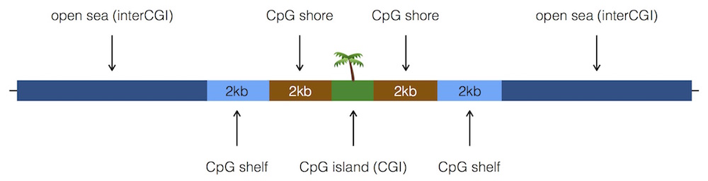

Cpg Annotations

## 3.2 Genic Annotations

Genic annotations include 1-5Kb upstream of the TSS, the promoter (< 1Kb upstream of the TSS - Transcriptional Start Site), 5?UTR, first exons, exons, introns, CDS, 3?UTR, and intergenic regions (the intergenic regions exclude the previous list of annotations). In Bioconductor, the genic annotations are determined by functions from `GenomicFeatures` and data from the `TxDb.*` and `org.*.eg.db` packages.

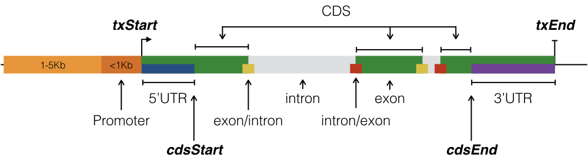

Geneic Annotations

## 3.3 Other types of annotations

- FANTOM5 permissive enhancers were determined from bi-directional CAGE transcription as in [Andersson et al. (2014)](https://www.nature.com/articles/nature12787)
- The long non-coding RNA (lncRNA) annotations are from [GENCODE](https://www.gencodegenes.org/) for hg19, hg38, and mm10. The lncRNA transcripts are used, and we eventually plan to include the lncRNA introns/exons at a later date.
- Chromatin states determined by chromHMM ([Ernst and Kellis (2012)](https://www.nature.com/articles/nmeth.1906)) in hg19 are available for nine cell lines (Gm12878, H1hesc, Hepg2, Hmec, Hsmm, Huvec, K562, Nhek, and Nhlf) via the UCSC Genome Browser tracks.

# 4 Case 1: Adding UCSC Annotation

- The UCSC data bases contain a multitude of genome annotation data for dozens of different organisms.
- Some of those data are very simple annotations like CpG island locations or SNP locations.
- Others are more complicated gene models, or even numeric annotations like conservation information.
- In order to provide a unified interface to all this information, the Gviz package defines a meta-constructor function UcscTrack.
- The idea here is that we can express all of the available UCSC data in one of the package?s track types.
- We can use the functionality provided in the `rtracklayer` package to connect to UCSC and to download the relevant information.

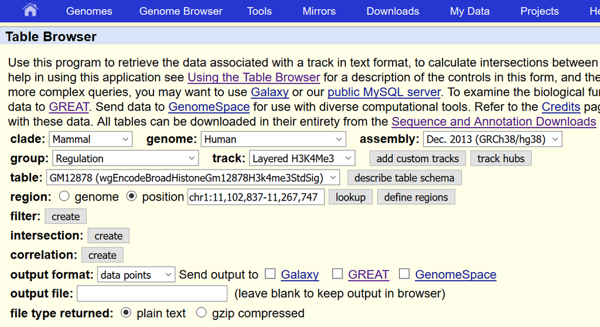

UCSC Table browser

This is one of the typical figures corresponding to the region chrX:65921878-65980988 wich is obtained from the UCSC web browser. This figure can be incorporated into the main paper or in the supplementary material to provide biological insights about main findings:

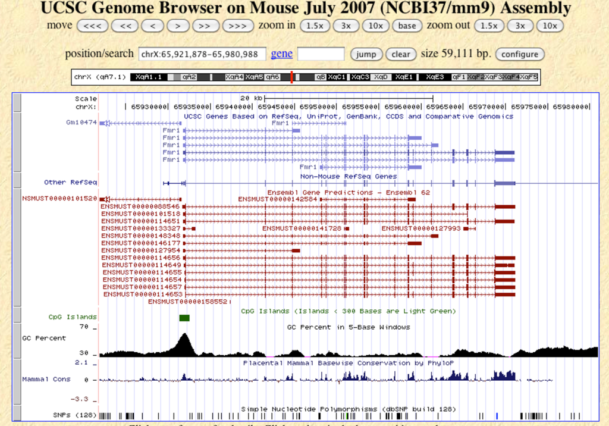

UCSC web browser

It can be created in R by using the `GViz` package as illustrated [here](https://bioconductor.org/packages/release/bioc/vignettes/Gviz/inst/doc/Gviz.html#5_creating_tracks_from_ucsc_data).

The different types of tracks available at `Gviz` can be found [here](https://bioconductor.org/packages/release/bioc/vignettes/Gviz/inst/doc/Gviz.html#4_track_classes). This vignette describe the different types of tracks that can be visualize and that are summarized here:

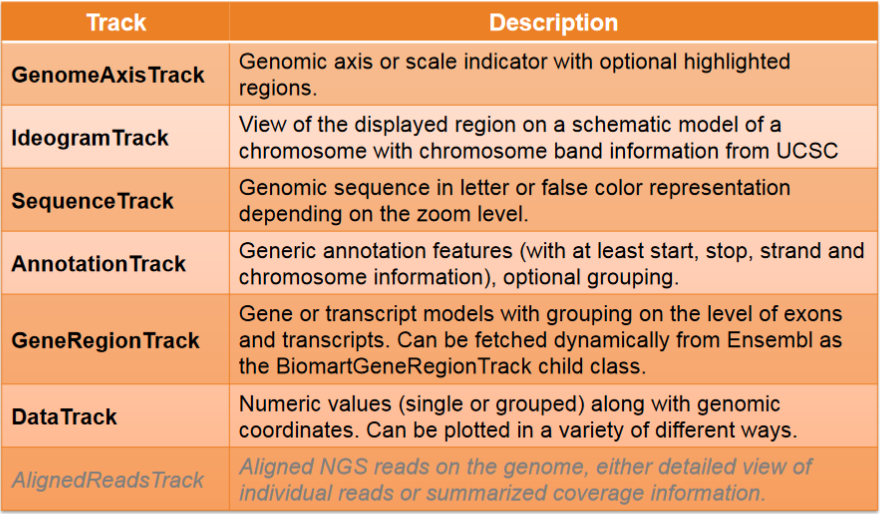

Track types

We can fetch data directly from UCSC. Let us start by retreiving the UCSC genes:

```r
library(Gviz)
from <- 65921878
to <- 65980988
knownGenes <- UcscTrack(genome="mm9", chromosome="chrX",
                        track="knownGene", from=from, to=to,
                        trackType="GeneRegionTrack",
                        rstarts="exonStarts",
                        rends="exonEnds", gene="name",
                        symbol="name", transcript="name",
                        strand="strand", fill="#8282d2",
                        name="UCSC Genes")
```

Using the same function we can build the next two gene model tracks based on the *xenoRefGene* and *ensGene* data tables.

```r
library(Gviz)
refGenes <- UcscTrack(genome="mm9", chromosome="chrX",
                      track="xenoRefGene", from=from, to=to,
                      trackType="GeneRegionTrack",
                      rstarts="exonStarts", rends="exonEnds",
                      gene="name",
                      symbol="name2", transcript="name",
                      strand="strand", fill="#8282d2",
                      stacking="dense", name="Other RefSeq")

ensGenes <- UcscTrack(genome="mm9", chromosome="chrX",
                      track="ensGene", from=from, to=to,
                      trackType="GeneRegionTrack",
                      rstarts="exonStarts", rends="exonEnds",
                      gene="name",
                      symbol="name2", transcript="name",
                      strand="strand", fill="#960000",
                      name="Ensembl Genes")
```

Then, we need to create the CpG and SNP tracks. These are slightly different since a `GeneRegionTrack` class would not be the most adequated. Instead, we can use `AnnotationTrack` objects as containers:

```r
cpgIslands <- UcscTrack(genome="mm9", chromosome="chrX",
                        track="cpgIslandExt", from=from,
                        to=to, trackType="AnnotationTrack",
                        start="chromStart", end="chromEnd",
                        id="name", shape="box",
                        fill="#006400", name="CpG Islands")

snpLocations <-  UcscTrack(genome="mm9", chromosome="chrX",
                           track="snp128", from=from, to=to,
                           trackType="AnnotationTrack",
                           start="chromStart", end="chromEnd",
                           id="name",  feature="func",
                           strand="strand", shape="box",
                           stacking="dense", fill="black",
                           name="SNPs")
```

Then, most of UCSC?s data can be encapsulated as `DataTrack` class. For instance, the conservation information and GC-content can be annotated using:

```r
conservation <- UcscTrack(genome="mm9", chromosome="chrX",
                          track="Conservation",
                          table="phyloP30wayPlacental",
                          from=from, to=to,
                          trackType="DataTrack",
                          start="start", end="end",
                          data="score",
                          type="hist", window="auto",
                          col.histogram="darkblue",
                          fill.histogram="darkblue",
                          ylim=c(-3.7, 4),
                          name="Conservation")

gcContent <- UcscTrack(genome="mm9", chromosome="chrX",
                       track="GC Percent", table="gc5Base",
                       from=from, to=to,
                       trackType="DataTrack", start="start",
                       end="end", data="score",
                       type="hist", window=-1,
                       windowSize=1500,
                       fill.histogram="black",
                       col.histogram="black",
                       ylim=c(30, 70), name="GC Percent")
```

To understand which tables are available we can query the `rtracklayer` package to identify track and table names as following

```r
library(rtracklayer)
session <- browserSession()
genome(session) <- "hg19"
trackNames(session)[1:20]
```

```
     Base Position  GRC Patch Release     Alt Haplotypes           Assembly      BAC End Pairs          BU ORChID
           "ruler"      "hg19Patch13"     "altLocations"             "gold"      "bacEndPairs" "wgEncodeBuOrchid"
   Chromosome Band      deCODE Recomb       ENCODE Pilot        FISH Clones   Fosmid End Pairs                Gap
        "cytoBand"       "decodeRmap"    "encodeRegions"       "fishClones"      "fosEndPairs"              "gap"
        GC Percent       GRC Incident    GRC Map Contigs          Hg18 Diff          Hg38 Diff       Hi Seq Depth
         "gc5Base"    "grcIncidentDb"          "ctgPos2"   "hg19ContigDiff"   "hg38ContigDiff"       "hiSeqDepth"
             INSDC        LRG Regions
     "ucscToINSDC"              "lrg"
```

Once all the annotation data has been retreived, we start by creating a track wich encodes the genome axis and the ideogram of the X chromosome:

```r
axTrack <- GenomeAxisTrack()
idxTrack <- IdeogramTrack(genome="mm9", chromosome="chrX")
```

Then, we are ready to create the figure which includes all the required tracks:

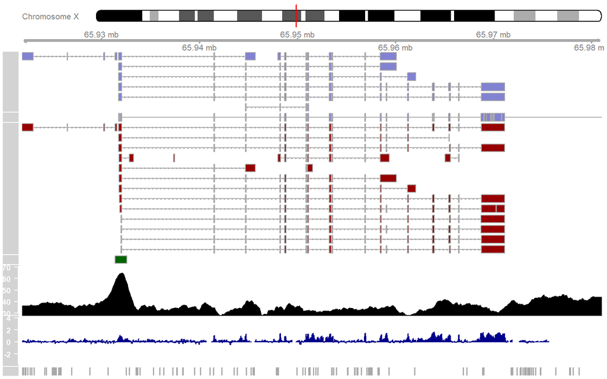

```r
plotTracks(list(idxTrack, axTrack, knownGenes, refGenes,
                ensGenes, cpgIslands,
                gcContent, conservation, snpLocations),
           from=from, to=to, showTitle=FALSE)
```

# 5 Case 2: Adding GWAS catalog hits

```r
library(gwascat)
data(ebicat37) # gwas catalog - h19 coordinates
roi <- GRanges(seqnames="chr8",
               IRanges(start = 48e6, end = 56e6))

gwas <- gwcex2gviz(basegr = ebicat37,
                   contextGR=roi, plot.it=FALSE)
gwasTrack <- gwas[[1]]
gwasTrack
```

```
DataTrack '-log P GWAS'
| genome: hg19
| active chromosome: chr8
| positions: 25
| samples:1
| strand: *
```

```r
genesTrack <- gwas[[3]]
genesTrack
```

```
GeneRegionTrack 'Genes'
| genome: hg19
| active chromosome: chr8
| annotation features: 377
```

Then, the plot can be created by:

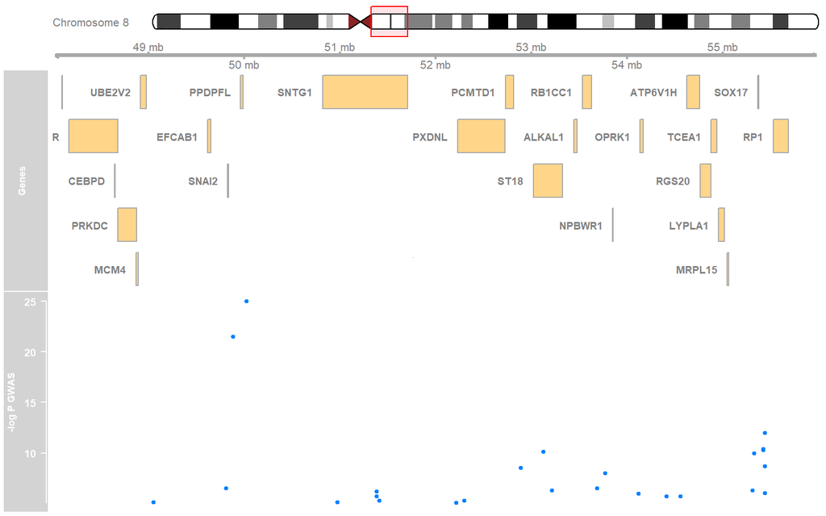

```r
gtrack <- GenomeAxisTrack()
itrack <- IdeogramTrack(genome = "hg19",
                        chromosome = "chr8")

plotTracks(list(itrack, gtrack, genesTrack,
                gwasTrack),
           from = start(roi),
           to = end(roi))
```

# 6 Case 2: Genomic Regions and Roadmap Epigenomics

All Roadmap Epigenomics files are hosted [here](https://egg2.wustl.edu/roadmap/data/byFileType/). There are several datasets that can be used for interpreting our results:

[figure not shown]

RoadMap Epigenomics

For instance, several studies are interested in annotating cromatine marks:

- H3K4me3: commonly associated with the activation of transcription of nearby genes.
- H3K4me1: considered active or primed enhancers.
- H3K36me3: play roles in many important biological processes such as DNA replication, transcription, recombination and repair of DNA damage.
- H3K27me3: is used in epigenetics to look for inactive genes.
- H3K9me3: has a pivotal role in embryonic stem cells at the onset of organogenesis during lineage commitment, and also a role in lineage fidelity maintenance.
- H3K27ac: is associated with the higher activation of transcription and therefore defined as an active enhancer mark

This is a real example:

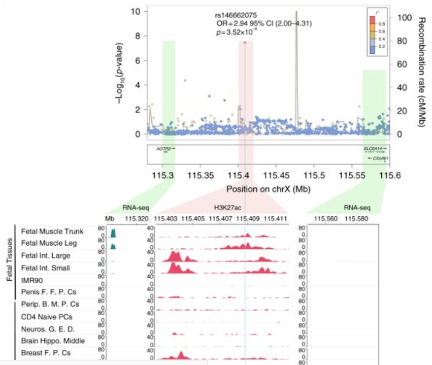

Example (Bon?s-Guarch, et al. Nat Comm, 2018)

This code illustrate how to obtain, for instance, annotation Layered H3K27Ac

```r
H3K4me3 <- UcscTrack(genome = "hg19",
                     chromosome = seqnames(region),
                     track = "Layered H3K27Ac",
                     table = "wgEncodeBroadHistoneHsmmH3k4me3StdSig",
                     from=1, to=10e6,
                     trackType = "DataTrack",
                     start = "start",
                     end = "end", data="score", type="hist",
                     window=-1, windowSize=1500,
                     fill.histogram="orange",
                     col.histogram="orange", name="H3K27Ac")
```

However, this can have problems for large regions. `AnnotationHub` package can help to manage annotations from different projects, in particular from RoadMap Epigenomics.

```r
library(AnnotationHub)
ah <- AnnotationHub()

H3K27Ac <- query(ah , c("EpigenomeRoadMap", "H3K27Ac"))
H3K27Ac
```

```
AnnotationHub with 1387 records
# snapshotDate(): 2018-10-24
# $dataprovider: BroadInstitute
# $species: Homo sapiens
# $rdataclass: GRanges, BigWigFile
# additional mcols(): taxonomyid, genome, description, coordinate_1_based, maintainer, rdatadateadded,
#   preparerclass, tags, rdatapath, sourceurl, sourcetype
# retrieve records with, e.g., 'object[["AH28887"]]'

            title
  AH28887 | E003-H3K27ac.broadPeak.gz
  AH28911 | E004-H3K27ac.broadPeak.gz
  AH28933 | E005-H3K27ac.broadPeak.gz
  AH28957 | E006-H3K27ac.broadPeak.gz
  AH28979 | E007-H3K27ac.broadPeak.gz
  ...       ...
  AH46829 | UW.Fetal_Muscle_Leg.H3K27ac.H-24644.Histone.DS21782.gappedPeak.gz
  AH46835 | UW.Fetal_Muscle_Trunk.H3K27ac.H-24851.Histone.DS23303.gappedPeak.gz
  AH46841 | UW.Fetal_Placenta.H3K27ac.H-24996.Histone.DS23301.gappedPeak.gz
  AH46847 | UW.Fetal_Stomach.H3K27ac.H-24683.Histone.DS22929.gappedPeak.gz
  AH46853 | UW.Fetal_Thymus.H3K27ac.H-24644.Histone.DS21783.gappedPeak.gz
```

Let us imagine we performed a transcriptomic data analysis on asthma. Then, one may be interested in creating the `DataTrack`s for data obtained in lung tissue and compare it, for instance, with other tissues such as stomach and bladder. The idea is to see whether our hits map over that regions

```r
H3K27Ac[grep("Lung", H3K27Ac$title),]
```

```
AnnotationHub with 10 records
# snapshotDate(): 2018-10-24
# $dataprovider: BroadInstitute
# $species: Homo sapiens
# $rdataclass: GRanges, BigWigFile
# additional mcols(): taxonomyid, genome, description, coordinate_1_based, maintainer, rdatadateadded,
#   preparerclass, tags, rdatapath, sourceurl, sourcetype
# retrieve records with, e.g., 'object[["AH35245"]]'

            title
  AH35245 | UCSD.Lung.H3K27ac.STL001.fc.signal.bigwig
  AH35246 | UCSD.Lung.H3K27ac.STL002.fc.signal.bigwig
  AH37160 | UCSD.Lung.H3K27ac.STL001.pval.signal.bigwig
  AH37161 | UCSD.Lung.H3K27ac.STL002.pval.signal.bigwig
  AH43010 | UCSD.Lung.H3K27ac.STL001.broadPeak.gz
  AH43011 | UCSD.Lung.H3K27ac.STL002.broadPeak.gz
  AH44565 | UCSD.Lung.H3K27ac.STL001.narrowPeak.gz
  AH44566 | UCSD.Lung.H3K27ac.STL002.narrowPeak.gz
  AH46480 | UCSD.Lung.H3K27ac.STL001.gappedPeak.gz
  AH46481 | UCSD.Lung.H3K27ac.STL002.gappedPeak.gz
```

```r
H3K27Ac[grep("Stomach", H3K27Ac$title),]
```

```
AnnotationHub with 10 records
# snapshotDate(): 2018-10-24
# $dataprovider: BroadInstitute
# $species: Homo sapiens
# $rdataclass: GRanges, BigWigFile
# additional mcols(): taxonomyid, genome, description, coordinate_1_based, maintainer, rdatadateadded,
#   preparerclass, tags, rdatapath, sourceurl, sourcetype
# retrieve records with, e.g., 'object[["AH34756"]]'

            title
  AH34756 | BI.Stomach_Smooth_Muscle.H3K27ac.28.fc.signal.bigwig
  AH35875 | UW.Fetal_Stomach.H3K27ac.H-24683.Histone.DS22929.fc.signal.bigwig
  AH36671 | BI.Stomach_Smooth_Muscle.H3K27ac.28.pval.signal.bigwig
  AH37790 | UW.Fetal_Stomach.H3K27ac.H-24683.Histone.DS22929.pval.signal.bigwig
  AH42521 | BI.Stomach_Smooth_Muscle.H3K27ac.28.broadPeak.gz
  AH43377 | UW.Fetal_Stomach.H3K27ac.H-24683.Histone.DS22929.broadPeak.gz
  AH44076 | BI.Stomach_Smooth_Muscle.H3K27ac.28.narrowPeak.gz
  AH45195 | UW.Fetal_Stomach.H3K27ac.H-24683.Histone.DS22929.narrowPeak.gz
  AH45991 | BI.Stomach_Smooth_Muscle.H3K27ac.28.gappedPeak.gz
  AH46847 | UW.Fetal_Stomach.H3K27ac.H-24683.Histone.DS22929.gappedPeak.gz
```

```r
H3K27Ac[grep("Bladder", H3K27Ac$title),]
```

```
AnnotationHub with 5 records
# snapshotDate(): 2018-10-24
# $dataprovider: BroadInstitute
# $species: Homo sapiens
# $rdataclass: GRanges, BigWigFile
# additional mcols(): taxonomyid, genome, description, coordinate_1_based, maintainer, rdatadateadded,
#   preparerclass, tags, rdatapath, sourceurl, sourcetype
# retrieve records with, e.g., 'object[["AH34860"]]'

            title
  AH34860 | UCSD.Bladder.H3K27ac.STL003.fc.signal.bigwig
  AH36775 | UCSD.Bladder.H3K27ac.STL003.pval.signal.bigwig
  AH42625 | UCSD.Bladder.H3K27ac.STL003.broadPeak.gz
  AH44180 | UCSD.Bladder.H3K27ac.STL003.narrowPeak.gz
  AH46095 | UCSD.Bladder.H3K27ac.STL003.gappedPeak.gz
```

Then, the selected databases are:

```r
ids <- c("AH44566", "AH44076", "AH44180")
peaks <- list()
for (i in ids){
 peaks[[i]] <- H3K27Ac[[i]]
}

peaksTrack <- lapply(peaks, DataTrack, data="score",
                     type="mountain", ylim=c(0,100),
                     name="H3K27Ac")
```

```r
library(GenomicRanges)
rois <- read.delim("data/ng.3570-S2.txt", comment.char = "#",
                  as.is=TRUE)
colnames(rois)
```

```
[1] "chr"     "st"      "sp"      "maxsize" "count"   "phenos"  "snps"
```

```r
regionsGR <- makeGRangesFromDataFrame(rois, seqnames="chr",
                                      start.field = "st",
                                      end.field = "sp")
regionsGR
```

```
GRanges object with 348 ranges and 0 metadata columns:
        seqnames              ranges strand
           <Rle>           <IRanges>  <Rle>
    [1]     chr1     1892607-3582736      *
    [2]     chr1     7247335-9365199      *
    [3]     chr1    9365199-10806984      *
    [4]     chr1   18662899-20469149      *
    [5]     chr1   21736588-23086883      *
    ...      ...                 ...    ...
  [344]     chr9 122260297-124871322      *
  [345]     chr9 126971887-129059665      *
  [346]     chr9 129059665-130055510      *
  [347]     chr9 133223217-134127888      *
  [348]     chr9 135298842-137041122      *
  -------
  seqinfo: 22 sequences from an unspecified genome; no seqlengths
```

Let us imagine we want to create a plot including all the pleiotropic regions in chr1:1.0Mb-100.0Mb

```r
rr <- GRanges(seqnames = "chr1",
              IRanges(start = 1e6, end=100e6))
rr2 <- subsetByOverlaps(regionsGR, rr)
roi <- AnnotationTrack(rr2, name="ROI")
```

The plot is created by:

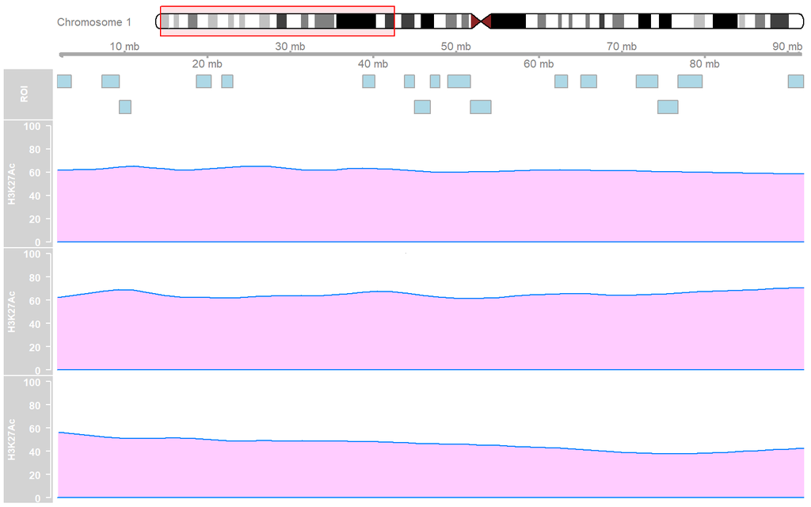

```r
gtrack <- GenomeAxisTrack()
itrack <- IdeogramTrack(genome = "hg19",
                        cromosome=seqnames(rr2))


plotTracks(c(itrack, gtrack, roi, peaksTrack),
           from = min(start(rr2)),
           to = max(end(rr2)))
```

Note the use of `chromosome = seqnames(rr2)`, `min(start(rr2))` and `max(end(rr2))`

We can add gene symbols in another track to make the plot more informative.

```r
library(GenomicFeatures)
library(TxDb.Hsapiens.UCSC.hg19.knownGene)
library(org.Hs.eg.db)
allg <- genes(TxDb.Hsapiens.UCSC.hg19.knownGene)
allg.range <- subsetByOverlaps(allg, rr2)
allg.range$symbol <- mapIds(Homo.sapiens::Homo.sapiens,
                                keys=allg.range$gene_id,
                                keytype="ENTREZID",
                                column="SYMBOL")

genes <- GeneRegionTrack(allg.range, genome = "hg19",
                         chromosome = seqnames(rr2),
                         showId=TRUE,
                         geneSymbol=TRUE,
                         start = min(start(rr2)),
                         end = max(end(rr2)),
                         name = "Genes")
```

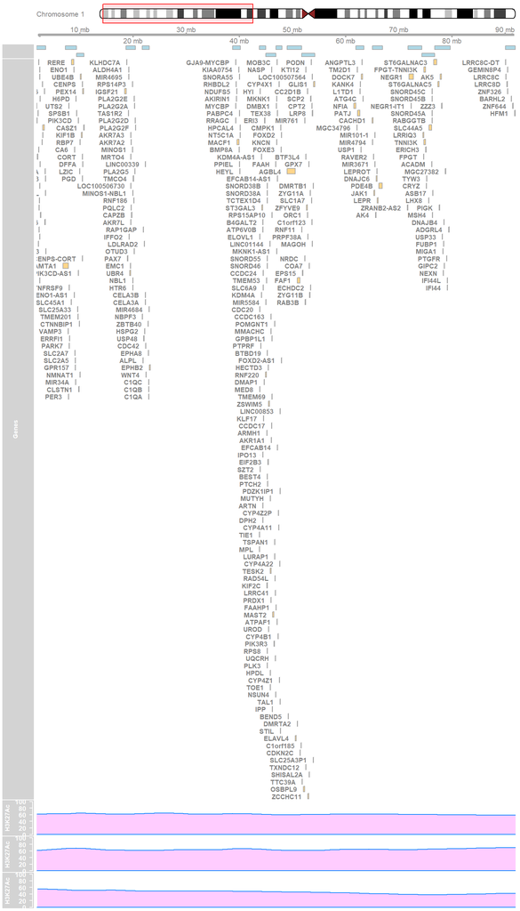

```r
gtrack <- GenomeAxisTrack()
itrack <- IdeogramTrack(genome = "hg19",
                        cromosome=seqnames(rr2))

plotTracks(c(itrack, gtrack, roi, genes, peaksTrack),
           from = min(start(rr2)),
           to = max(end(rr2)))
```

# 7 Case 3: Circos plot of gene expression or methylation data analysis

## 7.1 Differential expression analysis

- `limma` is the reference package to analyze both transcriptomic and epigenomic data
- Linear models are fitted to each feature
- Variance is estimated by modeling mean-variance relationship
- RNA-seq are count data, so that, negative binomial regression is required (`edgeR`, `DESeq2`). However, `voom` transformation can be used to get normal data.

## 7.2 Differential expression analysis

Let us determine the genes that are differentially expressed (DE) between healthy individuals and smokers with severe asthma.

```r
library(limma)
load("data/GSE69683.Rdata")
design <- model.matrix( ~ characteristics_ch1,
                        data=gse69683.expr)
colnames(design)
```

```
[1] "(Intercept)"                                             "characteristics_ch1cohort: Moderate asthma, non-smoking"
[3] "characteristics_ch1cohort: Severe asthma, non-smoking"   "characteristics_ch1cohort: Severe asthma, smoking"
```

```r
fit <- lmFit(gse69683.expr, design)
fit <- eBayes(fit)
de <- topTable(fit, coef=4)
de[1:5 , c(17:22)]
```

```
                    logFC   AveExpr         t      P.Value    adj.P.Val        B
202299_PM_s_at  0.3249308  9.376566  7.804433 3.547930e-14 1.941250e-09 21.46644
231500_PM_s_at -0.3079402 10.782530 -7.564833 1.890119e-13 3.682880e-09 19.87976
209167_PM_at   -0.6294318  5.710803 -7.555245 2.019307e-13 3.682880e-09 19.81707
231029_PM_at    0.7236442  6.511707  7.497400 3.005034e-13 4.110510e-09 19.44020
217370_PM_x_at -0.3545063  8.141787 -7.324709 9.709853e-13 1.062549e-08 18.32876
```

Inflation (produced by batch effects or uncontrolled variables) is normally tested by using QQ-plot

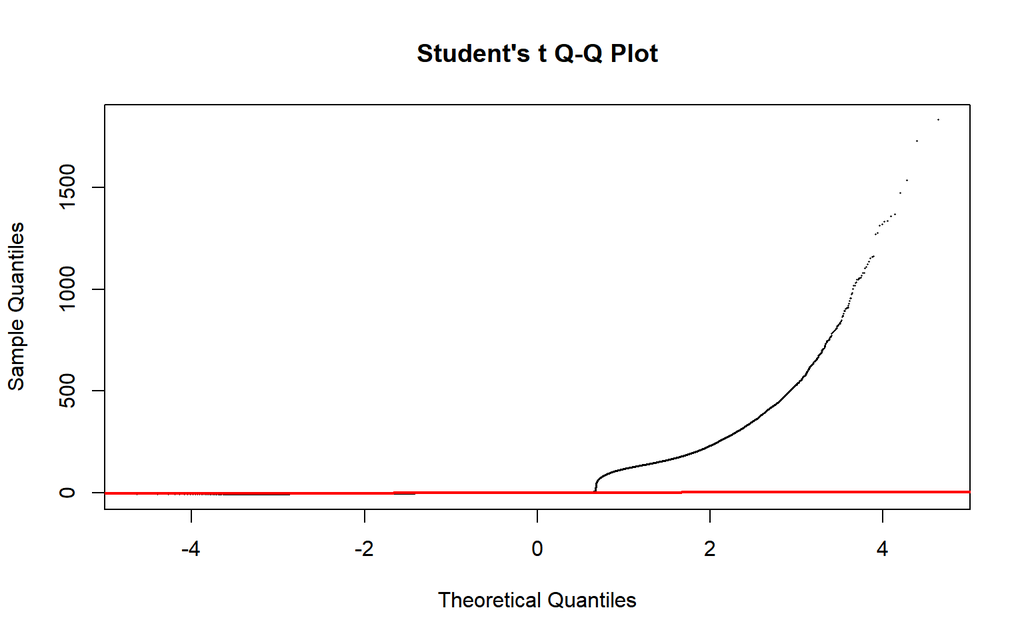

```r
qqt(fit$t, df=fit$df.prior+fit$df.residual,
    pch=16,cex=0.2)
abline(0,1, col="red", lwd=2)
```

Surrogate variable analysis (SVA) can be used to correct for uncontrolled variables. The [sva package](http://bioconductor.org/packages/release/bioc/vignettes/sva/inst/doc/sva.pdf) can be used to this end. This procedure is implemened in the [MEAL package](https://bioconductor.org/packages/release/bioc/html/MEAL.html) that requires less R code. Note that `fNames` argument allows to add annotation to the results by passing any of the existing variables in the feature data (`fData`) of the `ExpressionSet` object

```r
library(MEAL)
load("data/GSE69683.Rdata")

# shows available annotated variabels
names(fData(gse69683.expr))
```

```
 [1] "ID"                               "GB_ACC"                           "SPOT_ID"
 [4] "Species Scientific Name"          "Annotation Date"                  "Sequence Type"
 [7] "Sequence Source"                  "Target Description"               "Representative Public ID"
[10] "Gene Title"                       "Gene Symbol"                      "ENTREZ_GENE_ID"
[13] "RefSeq Transcript ID"             "Gene Ontology Biological Process" "Gene Ontology Cellular Component"
[16] "Gene Ontology Molecular Function"
```

```r
# DE analysis
ans <- runPipeline(gse69683.expr,
                   variable = "characteristics_ch1",
                   sva = TRUE)
ans
```

```
Object of class 'ResultSet'
 . created with: runPipeline
 . sva:  yes
 . #results: 2 ( error: 0 )
 . featureData: 54715 probes x 16 variables
```

```r
fit <- getProbeResults(ans, coef=4,
                       fNames=c("ID", "Gene Symbol"))
head(fit)
```

```
                    logFC       CI.L        CI.R   AveExpr         t      P.Value    adj.P.Val         B         SE
208524_PM_at    0.2382747  0.1693532  0.30719615  2.850703  6.793774 3.378371e-11 1.848476e-06 13.929594 0.06357005
206237_PM_s_at  0.5146101  0.3202569  0.70896338  5.907771  5.203248 2.951071e-07 8.073392e-03  6.052771 0.03122530
204881_PM_s_at -0.1455159 -0.2031693 -0.08786251  7.947932 -4.959906 9.928688e-07 1.563644e-02  5.006941 0.04350657
209840_PM_s_at  0.5425649  0.3263405  0.75878932  5.472731  4.930999 1.143119e-06 1.563644e-02  4.885652 0.04179924
200989_PM_at   -0.1011543 -0.1420524 -0.06025618 11.034880 -4.860365 1.608351e-06 1.760018e-02  4.591939 0.01876723
208230_PM_s_at  0.4682022  0.2760034  0.66040108  4.229076  4.787079 2.282196e-06 2.081173e-02  4.291200 0.02308808
                           ID Gene Symbol
208524_PM_at     208524_PM_at       GPR15
206237_PM_s_at 206237_PM_s_at        NRG1
204881_PM_s_at 204881_PM_s_at        UGCG
209840_PM_s_at 209840_PM_s_at       LRRN3
200989_PM_at     200989_PM_at       HIF1A
208230_PM_s_at 208230_PM_s_at        NRG1
```

The QQ-plot is then produced by

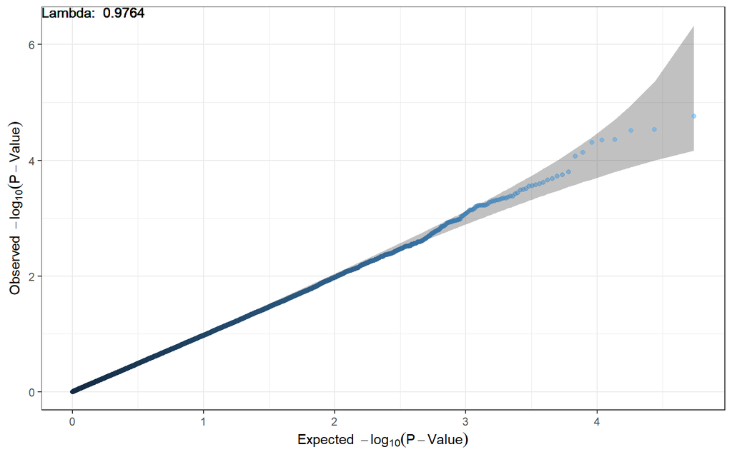

```r
plot(ans, type="QQ")
```

We normally represent those genes that pass 5% FDR threshold. In this example we will increase such value and will find those DE genes at 10% level:

```r
de <- fit[fit$adj.P.Val<0.1,]
dim(de)
```

```
[1] 24 11
```

```r
de
```

```
                     logFC        CI.L        CI.R   AveExpr         t      P.Value    adj.P.Val         B         SE
208524_PM_at    0.23827465  0.16935316  0.30719615  2.850703  6.793774 3.378371e-11 1.848476e-06 13.929594 0.06357005
206237_PM_s_at  0.51461015  0.32025692  0.70896338  5.907771  5.203248 2.951071e-07 8.073392e-03  6.052771 0.03122530
204881_PM_s_at -0.14551592 -0.20316933 -0.08786251  7.947932 -4.959906 9.928688e-07 1.563644e-02  5.006941 0.04350657
209840_PM_s_at  0.54256492  0.32634052  0.75878932  5.472731  4.930999 1.143119e-06 1.563644e-02  4.885652 0.04179924
200989_PM_at   -0.10115432 -0.14205245 -0.06025618 11.034880 -4.860365 1.608351e-06 1.760018e-02  4.591939 0.01876723
208230_PM_s_at  0.46820222  0.27600336  0.66040108  4.229076  4.787079 2.282196e-06 2.081173e-02  4.291200 0.02308808
218589_PM_at    0.18126965  0.10482905  0.25771025  7.405000  4.660032 4.142293e-06 3.237794e-02  3.779557 0.05702533
243909_PM_x_at -0.19691124 -0.28164805 -0.11217443  2.742570 -4.566530 6.368784e-06 4.355850e-02  3.410924 0.02511132
213808_PM_at    0.43866792  0.24807096  0.62926488  4.305000  4.522805 7.768423e-06 4.476018e-02  3.240854 0.03797298
202874_PM_s_at -0.17435980 -0.25056366 -0.09815594  6.948052 -4.496321 8.754902e-06 4.476018e-02  3.138568 0.03234201
226022_PM_at    0.40273445  0.22648036  0.57898855  5.669036  4.490219 8.998665e-06 4.476018e-02  3.115076 0.02730790
223204_PM_at    0.19864823  0.11004267  0.28725379  8.766606  4.405667 1.312314e-05 5.570393e-02  2.792569 0.02414317
224348_PM_s_at -0.50735630 -0.73406415 -0.28064845  5.391004 -4.397789 1.358850e-05 5.570393e-02  2.762807 0.02883569
203254_PM_s_at  0.08984527  0.04959972  0.13009082  9.972329  4.386976 1.425304e-05 5.570393e-02  2.722032 0.04336365
229629_PM_at    0.17461045  0.09533960  0.25388130  6.796486  4.328572 1.841503e-05 6.366880e-02  2.503376 0.03498597
209841_PM_s_at  0.45669634  0.24924155  0.66415112  5.907871  4.326055 1.861831e-05 6.366880e-02  2.494011 0.04195734
204409_PM_s_at  0.25567946  0.13906815  0.37229078  5.374137  4.308668 2.008193e-05 6.463427e-02  2.429472 0.03019441
221581_PM_s_at  0.09259640  0.04997511  0.13521770  9.196205  4.269287 2.381428e-05 7.238881e-02  2.284164 0.02726675
204675_PM_at    0.17243199  0.09223312  0.25263086  7.809257  4.225105 2.878842e-05 8.290308e-02  2.122597 0.02289400
200605_PM_s_at -0.08717232 -0.12817376 -0.04617089 10.422249 -4.177991 3.517831e-05 9.623907e-02  1.952007 0.03121189
205476_PM_at   -0.22750489 -0.33483572 -0.12017406  3.977711 -4.165376 3.710619e-05 9.667930e-02  1.906629 0.02271579
221718_PM_s_at  0.12231894  0.06445165  0.18018624  8.331305  4.153828 3.895887e-05 9.689248e-02  1.865200 0.03705242
1555580_PM_at   0.25455758  0.13375436  0.37536079  4.487269  4.140907 4.113611e-05 9.728477e-02  1.818972 0.03230149
239594_PM_at    0.17688932  0.09276707  0.26101158  3.428916  4.132174 4.267266e-05 9.728477e-02  1.787804 0.03409494
                           ID Gene Symbol
208524_PM_at     208524_PM_at       GPR15
206237_PM_s_at 206237_PM_s_at        NRG1
204881_PM_s_at 204881_PM_s_at        UGCG
209840_PM_s_at 209840_PM_s_at       LRRN3
200989_PM_at     200989_PM_at       HIF1A
208230_PM_s_at 208230_PM_s_at        NRG1
218589_PM_at     218589_PM_at       LPAR6
243909_PM_x_at 243909_PM_x_at      GUSBL2
213808_PM_at     213808_PM_at
202874_PM_s_at 202874_PM_s_at    ATP6V1C1
226022_PM_at     226022_PM_at       SASH1
223204_PM_at     223204_PM_at     FAM198B
224348_PM_s_at 224348_PM_s_at
203254_PM_s_at 203254_PM_s_at        TLN1
229629_PM_at     229629_PM_at
209841_PM_s_at 209841_PM_s_at       LRRN3
204409_PM_s_at 204409_PM_s_at      EIF1AY
221581_PM_s_at 221581_PM_s_at        LAT2
204675_PM_at     204675_PM_at      SRD5A1
200605_PM_s_at 200605_PM_s_at     PRKAR1A
205476_PM_at     205476_PM_at       CCL20
221718_PM_s_at 221718_PM_s_at      AKAP13
1555580_PM_at   1555580_PM_at
239594_PM_at     239594_PM_at   LOC145837
```

Let us create a variable indicating whether the gene is down- (red) or up-regulated (blue)

```r
de$sign <- ifelse(de$logFC < 0, "red", "blue")
table(de$sign)
```

```
blue  red
  17    7
```

A circos plot maps those DE genes along the genome. Then, we first need to get chromosome and position of genes. This task can be done using several Bioconductor packages `AnnotationHub`, `OrgDb` objects, `TxDb` objects, `biomaRt`. See [here](https://www.bioconductor.org/packages/devel/workflows/vignettes/annotation/inst/doc/Annotation_Resources.html). some examples

```r
library(org.Hs.eg.db)
# see columns(org.Hs.eg.db)
cols <- c("SYMBOL", "CHR", "CHRLOC", "CHRLOCEND"  )
annot <- select(org.Hs.eg.db, keys=de$"Gene Symbol",
                columns=cols,
                keytype="SYMBOL")
annot <- subset(annot, !duplicated(SYMBOL) & !is.na(CHR))
bd <- merge(annot, de, by.x="SYMBOL", by.y="Gene Symbol")
dim(bd)
```

```
[1] 18 16
```

```r
head(bd)
```

```
    SYMBOL CHR     CHRLOC CHRLOCCHR  CHRLOCEND      logFC        CI.L        CI.R  AveExpr         t      P.Value
1   AKAP13  15   85619949        15   85749358  0.1223189  0.06445165  0.18018624 8.331305  4.153828 3.895887e-05
2 ATP6V1C1   8  103021019         8  103073057 -0.1743598 -0.25056366 -0.09815594 6.948052 -4.496321 8.754902e-06
3    CCL20   2  227813841         2  227817564 -0.2275049 -0.33483572 -0.12017406 3.977711 -4.165376 3.710619e-05
4   EIF1AY   Y   20575710         Y   20593154  0.2556795  0.13906815  0.37229078 5.374137  4.308668 2.008193e-05
5  FAM198B   4 -158124579         4 -158173050  0.1986482  0.11004267  0.28725379 8.766606  4.405667 1.312314e-05
6    GPR15   3   98531898         3   98534679  0.2382747  0.16935316  0.30719615 2.850703  6.793774 3.378371e-11
     adj.P.Val         B         SE             ID sign
1 9.689248e-02  1.865200 0.03705242 221718_PM_s_at blue
2 4.476018e-02  3.138568 0.03234201 202874_PM_s_at  red
3 9.667930e-02  1.906629 0.02271579   205476_PM_at  red
4 6.463427e-02  2.429472 0.03019441 204409_PM_s_at blue
5 5.570393e-02  2.792569 0.02414317   223204_PM_at blue
6 1.848476e-06 13.929594 0.06357005   208524_PM_at blue
```

Let us start by drawin the chromosomes with their cytobands

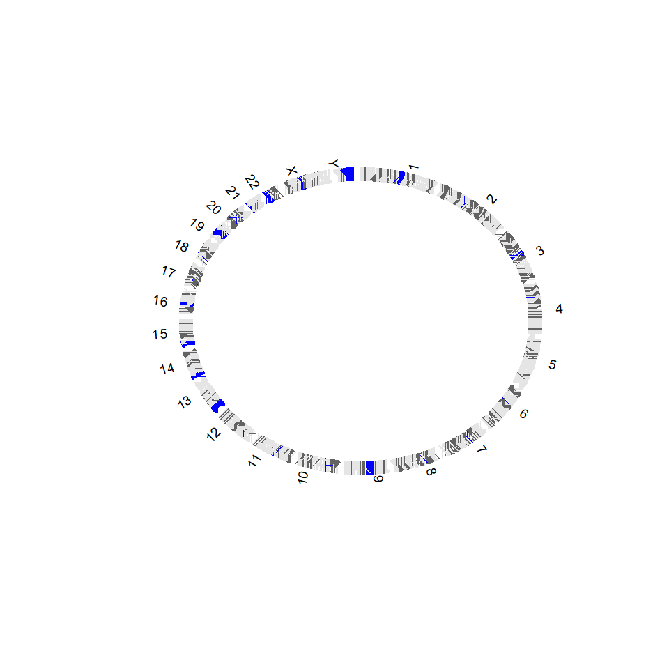

```r
library(OmicCircos)

plot(c(1,800), c(1,800),
     type="n", axes=FALSE, xlab="", ylab="")
circos(R=300, type="chr", cir="hg19", col=TRUE,
       print.chr.lab=TRUE, W=10, cex=2)
```

Then let us add the results of our transcriptomic data analysis and the gene symbols of the DE genes

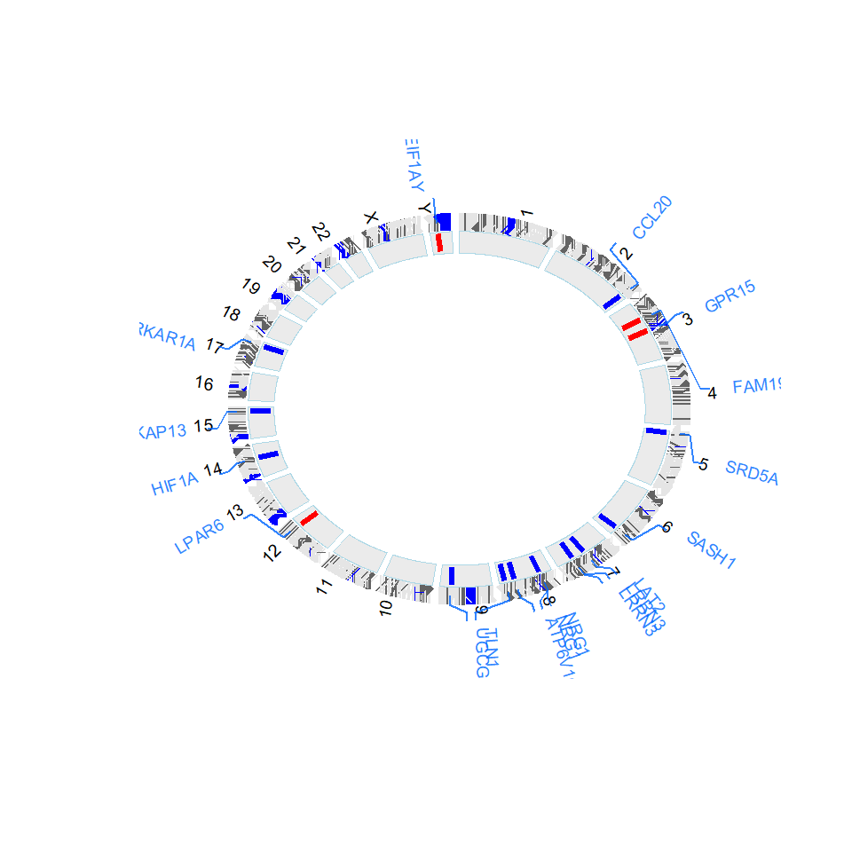

```r
plot(c(1,800), c(1,800),
     type="n", axes=FALSE, xlab="", ylab="")
circos(R=300, type="chr", cir="hg19", col=TRUE,
       print.chr.lab=TRUE, W=10, cex=2)

circos(R=250, cir="hg19", W=40,
      mapping = bd[,c("CHR", "CHRLOCEND", "logFC")],
      type="b3", lwd=3, B=TRUE, cutoff = 0,
      col=bd$sign)

circos(R=300, cir="hg19", W=40,
       mapping=bd[,c("CHR", "CHRLOCEND", "SYMBOL")],
       type="label", side="out", cex=0.6)
```

We can improve the plot by having more tracks. Let us assume we want to represent the DE genes for smokers and non-smoker asthmatics

```r
table(gse69683.expr$`characteristics_ch1`)
```

```
        cohort: Healthy, non-smoking cohort: Moderate asthma, non-smoking   cohort: Severe asthma, non-smoking
                                  87                                   77                                  246
      cohort: Severe asthma, smoking
                                  88
```

The DE genes for each group is obtained by

```r
ff <- list()
for (i in 1:2)
  ff[[i]] <- getProbeResults(ans, coef=i+2,
                       fNames=c("ID", "Gene Symbol"))
de <- lapply(ff, function(x) x[x$adj.P.Val<0.1,])
de <- lapply(de, function(x) cbind(x,
                                   sign=ifelse(x$logFC < 0,
                                               "red",
                                                "blue")))
de <- lapply(de, function(x) merge(annot, x,
                                   by.x="SYMBOL",
                                   by.y="Gene Symbol"))
head(de[[1]])
```

```
   SYMBOL CHR     CHRLOC CHRLOCCHR  CHRLOCEND       logFC        CI.L        CI.R   AveExpr         t      P.Value
1   CCL20   2  227813841         2  227817564 -0.20070852 -0.29209403 -0.10932300  3.977711 -4.315950 1.945607e-05
2 FAM198B   4 -158124579         4 -158173050  0.17316039  0.09771828  0.24860251  8.766606  4.510479 8.213497e-06
3   HIF1A  14   61695400        14   61748259 -0.08612904 -0.12095125 -0.05130683 11.034880 -4.860503 1.607284e-06
4    LAT2   7   74209756         7   74229834  0.08971266  0.05342328  0.12600203  9.196205  4.858051 1.626327e-06
5    UGCG   9  111896765         9  111935374 -0.13344433 -0.18253261 -0.08435605  7.947932 -5.342078 1.445594e-07
   adj.P.Val        B         SE             ID sign
1 0.09677625 2.554799 0.02325097   205476_PM_at  red
2 0.05253765 3.313973 0.02138072   223204_PM_at blue
3 0.02224611 4.756176 0.03704313   200989_PM_at  red
4 0.02224611 4.745737 0.03558945 221581_PM_s_at blue
5 0.00790957 6.896894 0.05412594 204881_PM_s_at  red
```

Then, the circos plot is created by:

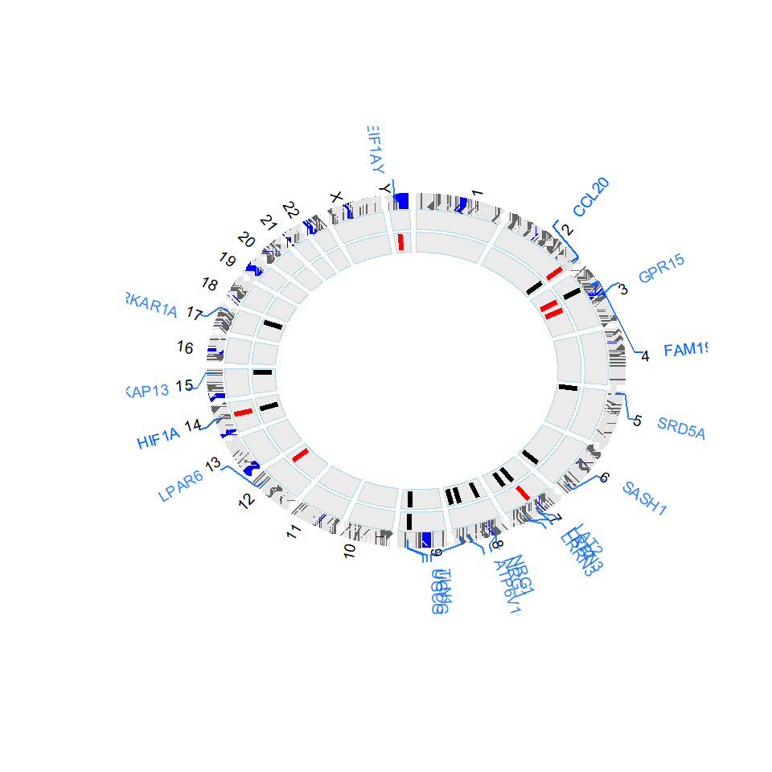

```r
plot(c(1,800), c(1,800), type="n",
     axes=FALSE, xlab="", ylab="")

circos(R=300, type="chr", cir="hg19", col=TRUE,
       print.chr.lab=TRUE, W=10, cex=2)

mycols <- c("green", "darkblue")
for (i in 1:2) {
  circos(R=300, cir="hg19", W=40,
       mapping=de[[i]][,c("CHR", "CHRLOCEND", "SYMBOL")],
       type="label", side="out", cex=0.6)

  circos(R=250 - 40*(i-1), cir="hg19", W=40,
       mapping = de[[i]][,c("CHR", "CHRLOCEND", "logFC")],
       type="b3", lwd=3, B=TRUE, cutoff = 0,
       col=de[[i]]$sign)
}
```

Other features for circos plot can be found [here](http://bioconductor.org/packages/release/bioc/vignettes/OmicCircos/inst/doc/OmicCircos_vignette.pdf).

**EXERCISE**: The file `GSE18123.Rdata` available [here](https://github.com/isglobal-brge/post_omic/blob/master/data_exercises/GSE18123.Rdata) contains data corresponding to the GEO accesion number GSE18123. This dataset was used to test whether peripheral blood gene expression profiles could be used as a molecular diagnostic tool for distinguishing children with Autistic Spectrum Disorder (ASD) from controls by performing peripheral blood gene expression profiling on 170 patients with ASD and 115 controls collected from Boston area hospitals.

1. Determine those genes that are differentially expressed between CONTROLs and the three types of ASD analyzed (AUTISM, PDD-NOS and ASPERGER’S DISORDER) (variable `group`).
2. Represent the results in a circos plot indicating with different colors those genes which are down- and up-regulated of each disorder
3. Select the gene most associated to AUTISM and determine its chromosome and position. Create a plot with the following tracks in window of $\pm$ 10Mb:
   - Exons from UCSC
   - CpG islands distribution
   - Cromatine marks of H3K27Ac of different tissues (Cingulate_Gyrus, Hippocampus and Mid_Frontal_Lobe that can be important for ASD and bladder as a control)
   - Hits from GWAS catalog

NOTE: You can use this code to annotate gene symbol

```
target <- "BRCA"
library(org.Hs.eg.db)
cols <- c("SYMBOL", "CHR", "CHRLOC", "CHRLOCEND"  )
annot <- select(org.Hs.eg.db, keys=target,
                columns=cols,
                keytype="SYMBOL")
annot
```